# Extreme Bounds Analysis

Marcelo Bohrer

## Introduction

This presentation is a brief show case of the Extreme Bounds package, which implements extreme bounds analysis in R. This type of analysis provides a distribution of the beta coefficients for a fixed set of variables in a multiple linear regression. The focus is not on developing the most accurate model, but to explore the possible values of the coefficients.

Extreme bounds analysis was developed by Leamer in 1983 and further developed by Sala-i-Martin in the late 90’s. The method has many applications, economists (such as Sala-i-Martin) used it to study economic growth. The R package implementing this analysis was developed by Marek Hlavac in 2016.

## Structure of the model

The basic structure is just that of a linear regression
$$y_i = \sum_i^n\beta_i x_i + \epsilon_i$$

### Variable Types

In EBA there are two (or three) types of variables:

- free: these variables will be included in every model, they form somewhat of a ‘prior knwoledge’ that the researcher has.
- focus: these are the variables whose robustness we want to test, at least 1 of these variables will be included in every regression.

```r
library(ExtremeBounds)
library(dplyr)
```

## Application - Videogame soccer (football) player ratings

In Fifa player’s have a global rating, plus ratings on many attributes. Ratings can (should be able to) be explained by some function of the attributes. It’s assumed that the model is linear. Ratings for all attributes are on a 0-100 scale, theoretically a linear regression should not be used, but the idea is to showcase the technique so a take some statitical liberties. We’ll focus for some reason on offensive players. Let’s take a look at the data.

```r
datafifa <- read.csv('C:/Users/mbohrer/Documents/Dus_rug/data_fifa.csv', sep = ',', stringsAsFactors = F)
glimpse(datafifa)
```

```
## Observations: 13,725
## Variables: 87
## $ X                        <int> 0, 1, 2, 3, 4, 5, 6, 7, 8, 9, 10, 11, 12, ...
## $ ID                       <int> 158023, 20801, 190871, 193080, 192985, 183...
## $ Name                     <chr> "L. Messi", "Cristiano Ronaldo", "Neymar J...
## $ Age                      <int> 31, 33, 26, 27, 27, 27, 32, 31, 32, 25, 26...
## $ Photo                    <chr> "https://cdn.sofifa.org/players/4/19/15802...
## $ Nationality              <chr> "Argentina", "Portugal", "Brazil", "Spain"...
## $ Flag                     <chr> "https://cdn.sofifa.org/flags/52.png", "ht...
## $ Overall                  <int> 94, 94, 92, 91, 91, 91, 91, 91, 91, 90, 90...
## $ Potential                <int> 94, 94, 93, 93, 92, 91, 91, 91, 91, 93, 91...
## $ Club                     <chr> "FC Barcelona", "Juventus", "Paris Saint-G...
## $ Club.Logo                <chr> "https://cdn.sofifa.org/teams/2/light/241....
## $ Value                    <chr> "Ã¢âÂ¬110.5M", "Ã¢âÂ¬77M", "Ã¢âÂ¬118.5M", "Ã¢âÂ¬72...
## $ Wage                     <chr> "Ã¢âÂ¬565K", "Ã¢âÂ¬405K", "Ã¢âÂ¬290K", "Ã¢âÂ¬260K"...
```

[output cut: 74 more lines]

### The naive model

Considering 14 independent variables we have 1470 regressions to estimate on a total of 3025 observations. Running these regressions takes a couple of minutes.

```r
datafifa <- datafifa %>%
  filter(Position %in% c('CAM', 'CM', 'LAM', 'LCM',  'LF', 'LM', 'LS', 'LW', 'RCM',  'RF', 'RM', 'RS', 'RW', 'ST'))

eba.fifa <-   eba(formula = Potential ~ Crossing + Curve + Dribbling + FKAccuracy + Finishing + HeadingAccuracy +
                    LongShots + Positioning + Reactions+ShortPassing + ShotPower +
                    SprintSpeed + Stamina  + Vision, data = datafifa)
```

```
## ExtremeBounds: eba() performing analysis. Please wait.
```

```
##
## Preparing variables (1/4): Done.
##
## Generating combinations (2/4): Estimate all 1470 combinations.
##
## Estimating regressions (3/4):
## 1 / 1470 (0.07%)
## 147 / 1470 (10%)
## 294 / 1470 (20%)
## 441 / 1470 (30%)
## 588 / 1470 (40%)
## 735 / 1470 (50%)
## 882 / 1470 (60%)
## 1029 / 1470 (70%)
## 1176 / 1470 (80%)
## 1323 / 1470 (90%)
## 1470 / 1470 (100%)
##
## Calculating bounds (4/4): Done.
```

We can see the results in the chart:

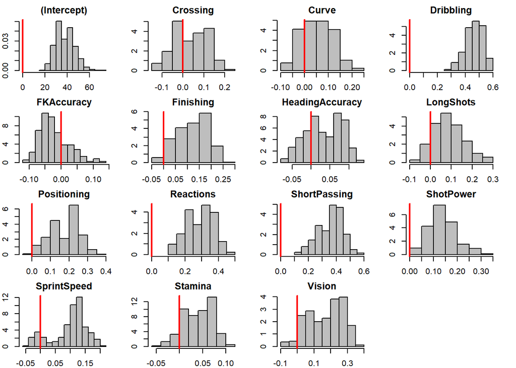

```r
hist(eba.fifa , density.show = F)
```

We can see that Dribbling, Reactions and ShortPassing seem to be robust variables. But what about the others?

```r
summary(eba.fifa)
```

```
##
## Call:
## eba(formula = Potential ~ Crossing + Curve + Dribbling + FKAccuracy +
##     Finishing + HeadingAccuracy + LongShots + Positioning + Reactions +
##     ShortPassing + ShotPower + SprintSpeed + Stamina + Vision,
##     data = datafifa)
##
## Confidence level: 0.95
## Number of combinations: 1470
## Regressions estimated: 1470 (100% of combinations)
##
## Number of regressions by variable:
##
##     (Intercept)        Crossing           Curve       Dribbling      FKAccuracy
##            1470             378             378             378             378
##       Finishing HeadingAccuracy       LongShots     Positioning       Reactions
##             378             378             378             378             378
##    ShortPassing       ShotPower     SprintSpeed         Stamina          Vision
##             378             378             378             378             378
##
## Number of coefficients used by variable:
##
##     (Intercept)        Crossing           Curve       Dribbling      FKAccuracy
##            1470             378             378             378             378
##       Finishing HeadingAccuracy       LongShots     Positioning       Reactions
##             378             378             378             378             378
##    ShortPassing       ShotPower     SprintSpeed         Stamina          Vision
##             378             378             378             378             378
##
## Beta coefficients:
##
##                   Type  Coef (Wgt Mean)  SE (Wgt Mean)  Min Coef  SE (Min Coef)
## (Intercept)       free           38.096          0.867    19.112          1.072
## Crossing         focus            0.037          0.010    -0.140          0.009
## Curve            focus            0.052          0.009    -0.080          0.008
## Dribbling        focus            0.465          0.013     0.263          0.016
## FKAccuracy       focus           -0.022          0.008    -0.113          0.009
## Finishing        focus            0.121          0.010    -0.023          0.012
## HeadingAccuracy  focus            0.034          0.008    -0.066          0.008
## LongShots        focus            0.087          0.012    -0.083          0.014
```

[output cut: 115 more lines]

```
## (Intercept)               100.000
## Crossing                   61.847
## Curve                      75.729
## Dribbling                 100.000
## FKAccuracy                 26.775
## Finishing                  96.628
## HeadingAccuracy            73.253
## LongShots                  88.154
## Positioning                99.420
## Reactions                 100.000
## ShortPassing              100.000
## ShotPower                  99.981
## SprintSpeed                88.810
## Stamina                    88.201
## Vision                     94.702
```

Let’s take a look at Vision. It was included in 378 regressions, the average $\beta$ was 0.171.

$\beta$ was $>0$ in 96.032% (363) regressions and both positive and significant (at 5%) in 88.89% (336) regressions.

Leamer’s method would classify Vision as fragile, since the lower extreme bound is -0.099 and the upper extrme bound is 0.381, so the interval contains 0, that means that for at least one combination of independent variables the beta coefficient for Vision was negative.

Sala-i-Martin’s method computes the CDF of the $\beta$ coefficients, using the integrated likelihood as weights. He uses two approaches, either assuming normality of the $\beta$ coefficients across models or with no distributional assumptions. Both are reported by the print() function. The results replicate the counts of $\beta$ we did before.

### using free variables

I can choose free variables to be included in every regression, this just requires minor changes in the code, and reduces the number of regressions thus reducing the computing time. This time Reactions, ShotPower, Dribbling and Vision will be included in every regression.

```r
library(ExtremeBounds)
eba.fifa <-   eba(formula = Potential ~ Reactions + ShotPower + Dribbling + Vision | Crossing + Curve + FKAccuracy + Finishing +                        HeadingAccuracy + LongShots + Positioning + ShortPassing +
                    SprintSpeed + Stamina , data = datafifa)
```

```
## ExtremeBounds: eba() performing analysis. Please wait.
```

```
##
## Preparing variables (1/4): Done.
##
## Generating combinations (2/4): Estimate all 385 combinations.
##
## Estimating regressions (3/4):
## 1 / 385 (0.26%)
## 39 / 385 (10.13%)
## 77 / 385 (20%)
## 116 / 385 (30.13%)
## 154 / 385 (40%)
## 193 / 385 (50.13%)
## 231 / 385 (60%)
## 270 / 385 (70.13%)
## 308 / 385 (80%)
## 347 / 385 (90.13%)
## 385 / 385 (100%)
##
## Calculating bounds (4/4): Done.
```

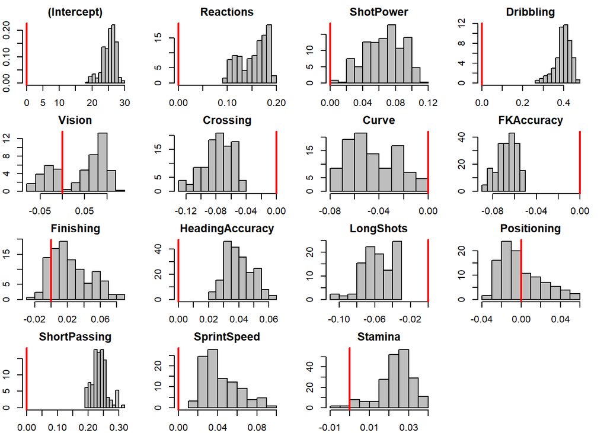

```r
hist(eba.fifa, density.show = F)
```

```r
print(eba.fifa)
```

```
##
## Call:
## eba(formula = Potential ~ Reactions + ShotPower + Dribbling +
##     Vision | Crossing + Curve + FKAccuracy + Finishing + HeadingAccuracy +
##     LongShots + Positioning + ShortPassing + SprintSpeed + Stamina,
##     data = datafifa)
##
## Confidence level: 0.95
## Number of combinations: 385
## Regressions estimated: 385 (100% of combinations)
##
## Number of regressions by variable:
##
##     (Intercept)       Reactions       ShotPower       Dribbling          Vision
##             385             385             385             385             385
##        Crossing           Curve      FKAccuracy       Finishing HeadingAccuracy
##             130             130             130             130             130
##       LongShots     Positioning    ShortPassing     SprintSpeed         Stamina
##             130             130             130             130             130
##
## Number of coefficients used by variable:
##
##     (Intercept)       Reactions       ShotPower       Dribbling          Vision
##             385             385             385             385             385
##        Crossing           Curve      FKAccuracy       Finishing HeadingAccuracy
##             130             130             130             130             130
##       LongShots     Positioning    ShortPassing     SprintSpeed         Stamina
##             130             130             130             130             130
##
## Beta coefficients:
##
##                   Type  Coef (Wgt Mean)  SE (Wgt Mean)  Min Coef  SE (Min Coef)
## (Intercept)       free           25.197          0.880    18.324          0.970
## Reactions         free            0.154          0.014     0.091          0.015
## ShotPower         free            0.066          0.012     0.007          0.012
## Dribbling         free            0.397          0.015     0.264          0.017
## Vision            free            0.041          0.012    -0.074          0.013
## Crossing         focus           -0.078          0.009    -0.128          0.009
## Curve            focus           -0.046          0.009    -0.075          0.008
## FKAccuracy       focus           -0.067          0.007    -0.086          0.006
```

[output cut: 115 more lines]

```
## (Intercept)               100.000
## Reactions                 100.000
## ShotPower                  99.693
## Dribbling                 100.000
## Vision                     69.119
## Crossing                    0.000
## Curve                       1.467
## FKAccuracy                  0.000
## Finishing                  82.279
## HeadingAccuracy            99.995
## LongShots                   0.093
## Positioning                45.168
## ShortPassing              100.000
## SprintSpeed                99.922
## Stamina                    96.353
```

### Different weights and goodness of fit

So far our average $\beta$ coefficients treated every regression the same way, but we can specify the weights to be according to adjusted R squared. Again it’s a minor code change.

```r
eba.fifa <-   eba(formula = Potential ~ Reactions + ShotPower + Dribbling + Vision | Crossing + Curve + FKAccuracy + Finishing +                        HeadingAccuracy + LongShots + Positioning + ShortPassing +
                    SprintSpeed + Stamina , data = datafifa,  weights = 'adj.r.squared')
```

```
## ExtremeBounds: eba() performing analysis. Please wait.
```

```
##
## Preparing variables (1/4): Done.
##
## Generating combinations (2/4): Estimate all 385 combinations.
##
## Estimating regressions (3/4):
## 1 / 385 (0.26%)
## 39 / 385 (10.13%)
## 77 / 385 (20%)
## 116 / 385 (30.13%)
## 154 / 385 (40%)
## 193 / 385 (50.13%)
## 231 / 385 (60%)
## 270 / 385 (70.13%)
## 308 / 385 (80%)
## 347 / 385 (90.13%)
## 385 / 385 (100%)
##
## Calculating bounds (4/4): Done.
```

```r
print(eba.fifa)
```

```
##
## Call:
## eba(formula = Potential ~ Reactions + ShotPower + Dribbling +
##     Vision | Crossing + Curve + FKAccuracy + Finishing + HeadingAccuracy +
##     LongShots + Positioning + ShortPassing + SprintSpeed + Stamina,
##     data = datafifa, weights = "adj.r.squared")
##
## Confidence level: 0.95
## Number of combinations: 385
## Regressions estimated: 385 (100% of combinations)
##
## Number of regressions by variable:
##
##     (Intercept)       Reactions       ShotPower       Dribbling          Vision
##             385             385             385             385             385
##        Crossing           Curve      FKAccuracy       Finishing HeadingAccuracy
##             130             130             130             130             130
##       LongShots     Positioning    ShortPassing     SprintSpeed         Stamina
##             130             130             130             130             130
##
## Number of coefficients used by variable:
##
##     (Intercept)       Reactions       ShotPower       Dribbling          Vision
##             385             385             385             385             385
##        Crossing           Curve      FKAccuracy       Finishing HeadingAccuracy
##             130             130             130             130             130
##       LongShots     Positioning    ShortPassing     SprintSpeed         Stamina
##             130             130             130             130             130
##
## Beta coefficients:
##
##                   Type  Coef (Wgt Mean)  SE (Wgt Mean)  Min Coef  SE (Min Coef)
## (Intercept)       free           25.155          0.880    18.324          0.970
## Reactions         free            0.153          0.014     0.091          0.015
## ShotPower         free            0.066          0.012     0.007          0.012
## Dribbling         free            0.396          0.015     0.264          0.017
## Vision            free            0.040          0.012    -0.074          0.013
## Crossing         focus           -0.078          0.009    -0.128          0.009
## Curve            focus           -0.046          0.009    -0.075          0.008
## FKAccuracy       focus           -0.067          0.007    -0.086          0.006
```

[output cut: 115 more lines]

```
## (Intercept)               100.000
## Reactions                 100.000
## ShotPower                  99.692
## Dribbling                 100.000
## Vision                     68.275
## Crossing                    0.000
## Curve                       1.479
## FKAccuracy                  0.000
## Finishing                  82.418
## HeadingAccuracy            99.995
## LongShots                   0.093
## Positioning                45.513
## ShortPassing              100.000
## SprintSpeed                99.923
## Stamina                    96.240
```

The print output is almost the same, there are minor changes to the weights of the coefficients.

And how are the adjusted r squared values for different regressions?

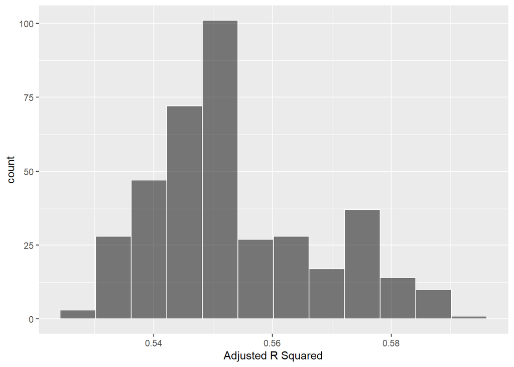

```r
library(ggplot2)
weightdf <- as.data.frame(eba.fifa$regressions$weight)
ggplot(weightdf, aes(x = `(Intercept)` )) +
  geom_histogram(bins = 12, alpha = 0.5 , col = 'white', fill = 'black') +
  xlab('Adjusted R Squared')
```

The values range between 0.5285 and 0.5944.

### Conclusion and additional development

There are many more things that can be implemented with this package:

- Logistic regression
- Variance inflation correction
- Limit the number of independent variables and mutually exclusive variables

### References

- Hlavac, Marek (2016). ExtremeBounds: Extreme Bounds Analysis in R. Journal of Statistical Software.
- Sala-i-Martin, Xavier (1997). I Just Ran Two Million Regressions. American Economic Review.
- Leamer E, Leonard H (1983). Reporting the Fragility of Regression Estimates. Review of Economics and Statistics.